# Analysis of the Ford GoBike System data from the San Francisco bay area.

## by Christabel Okosun

## Investigation Overview

> In this project, I used data visualization techniques to explore the San Francisco Bay Area bike usage data. THe purpose of this was to find trends in the data like most common user-type, common gender e.t.c

## Dataset Overview

> The dataset is the San Francisco Bay Area bike sharing data for Ford GoBike. The dataset contains 16 columns, the columns are:
- Duration in seconds
- Start time
- End time
- Start-station-id
- The name of the start-station
- The longtitude and latitude of the start station.
- End station-id
- The name of the end station
- The longtitude and latitude of the end station
- The bike id
- The type of the users
- Member information (birth year and gender)
- Bike share used for all trip (yes/no)

## What time do most trips start?

> Most of the trips started at 8 a.m and 5 p.m. This is considered the peak hours. At 8a.m, people leave to their respective places of work and return back by 5 p.m

```
Text(0.5,0,'')
```

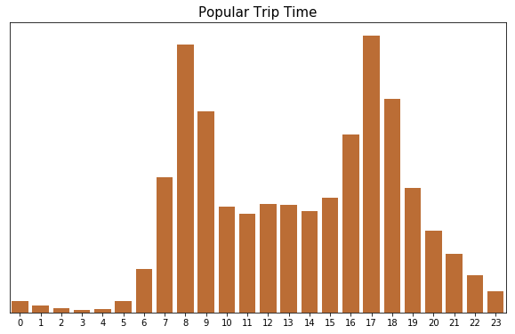

## What day of the week records the highest trip duration?

> During the weekend, the bike service records the highest trip duration. This might be because during the weekday they are just going to work and it is often a short trip but during the weekend, they are taking longer trips for leisure purposes.

```
Text(0.5,1,'Highest trip duration across days')
```

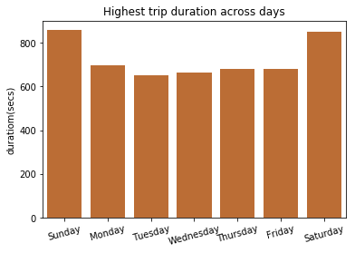

## What user type had the highest trip duration across all days?

> Across all days, the customer user type had the highest trip duration, having the highest days during the weekend. The subscriber user type had a consistent trip duration across all days.

```
Text(0.5,1,'Highest trip duration across days by user type')
```

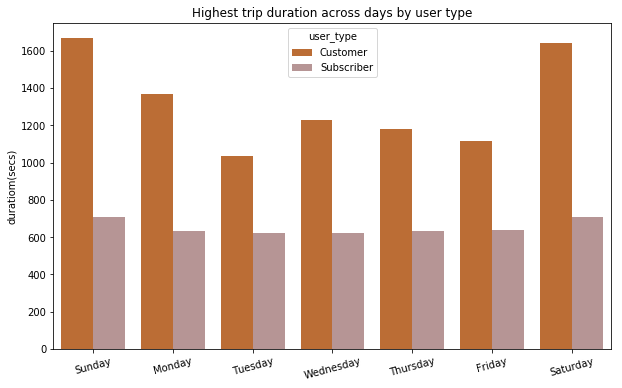